# FHAST Habitat Summary

January 10, 2023

### Simulation name: Arden Pond Pre

## Tabular Outputs

The habitat summary statistics. Units vary and are given next to each item name. CBC stands for cover bellow cuttoff percent which is the precent of area which is bellow the depth (0.5 m) and velocity (0.61 m/s) cuttoffs and has cover

| Item | Value |
| --- | --- |
| cover area (m²) | 246250.10 |
| near shore cover area (m²) | 227097.06 |
| near shore cover area bellow v (m²) | 127566.34 |
| percent area below v cutoff | 31.10 |
| percent area below d cutoff | 5.97 |
| percent near shore area | 42.76 |
| CBC percent | 2.13 |
| average cover percent | 14.31 |

The fish summary statistics for both juvenile and adult life stages of the 2 specie(s) of fish.

| Species | Life Stage | Metabolic Rate (j/day) |
| --- | --- | --- |
| chinook | adult | 4.342454e+05 |
| chinook | juvenile | 4.050610e+03 |
| green sturgeon | adult | 1.345953e+06 |
| green sturgeon | juvenile | 1.473133e+14 |

## Figures Outputs

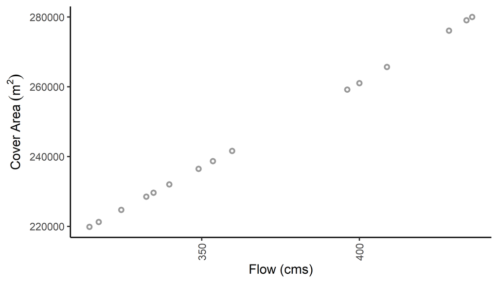

**Fig. 1** The amount of cover area that is is water shallower then the cutoff (0.5 m) for the level of flows present in the simulation.

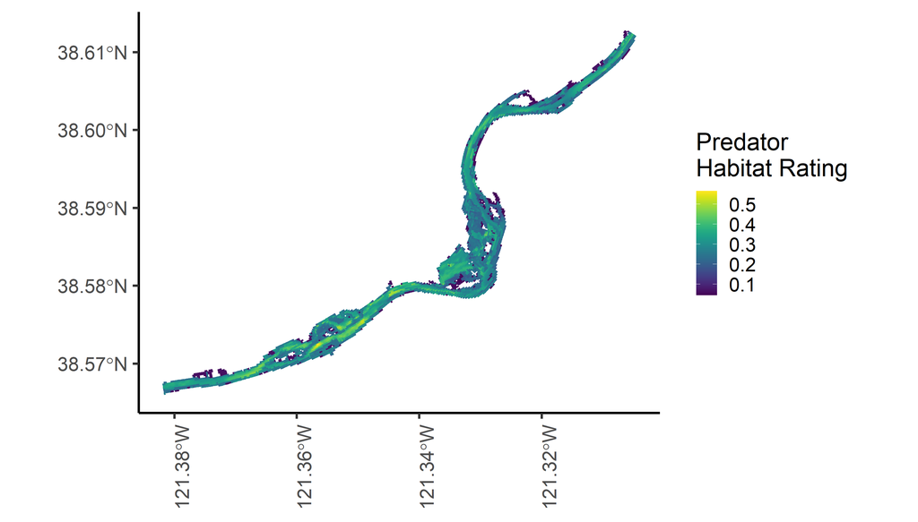

**Fig. 2** The predation rating map. This map shows the extent to which the preatotors selected (bass, pikeminnow) for this model will be attracted to areas. The attraction is abase on the average of the conditions in each area over the entire extent the the run (i.e. the start (10/01/1982) and end (10/15/1982) dates of the daily environmental conditions input file).

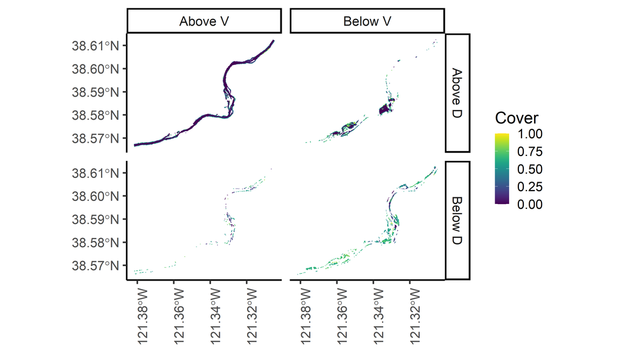

**Fig. 3** The fraction of an area that is undercover separated by sections that are on average above or bellow the depth and velocity cutoffs (0.5 m and 0.61 m/s respectively).

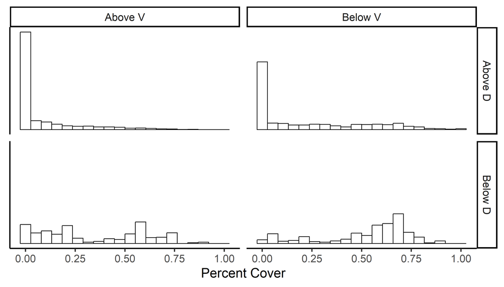

**Fig. 4** The density histograms of the area that is undercover separated by sections that are on average above or bellow the depth and velocity cutoffs (0.5 m and 0.61 m/s respectively).

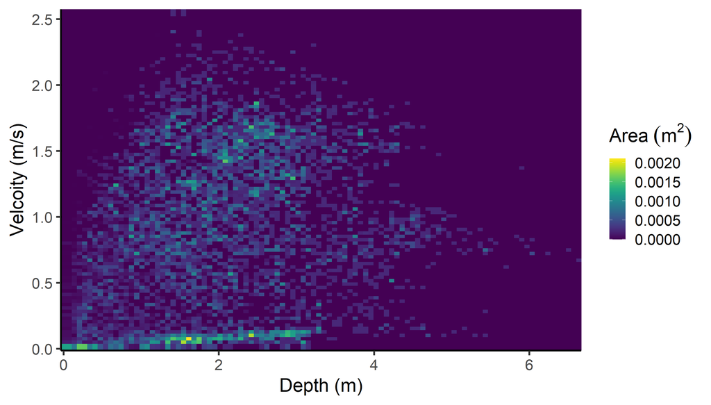

**Fig. 5** A heat map showing the fraction of area at set average depths and velocities over the time of the simulation (10/01/1982 to 10/15/1982) .

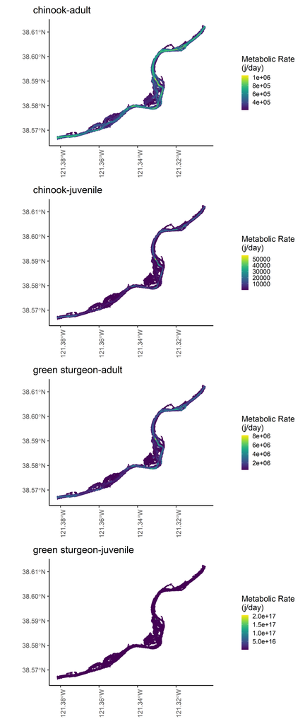

**Fig. 6** A set of maps showing the metabolic rate for both the juvenile and adult life stage of the simulated species of fish (chinook, green_sturgeon) if the fish swam at the water velocity and temperature of the cell for 24 hours.

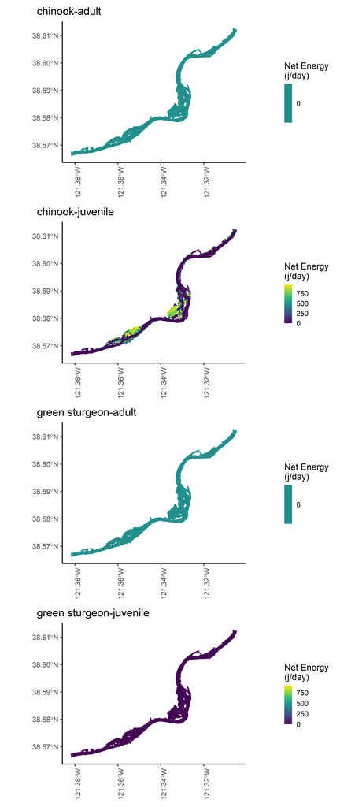

The net energy of the fish.

**Fig. 7** A set of maps showing the net energy budget for both the juvenile and adult life stage of the simulated species of fish (chinook, green_sturgeon) if the fish swam at the water velocity and temperature of the cell for 24 hours and consumed food.

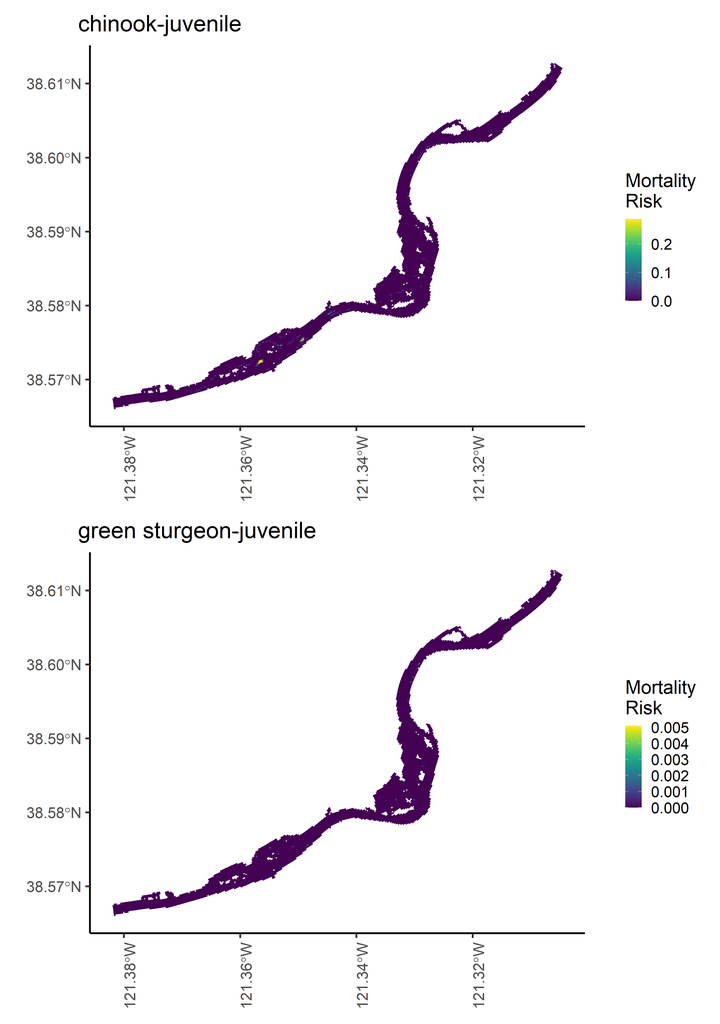

**Fig. 8** A set of maps showing the mortality rate for the juvenile life stage (represented by fish of length 5, 13 cm) of the fish species (chinook, green_sturgeon).

## Appendix

### Run inputs

The main input file:

```
## simulation name = Arden Pond Pre
## fish population = Arden_pond_Pre/fish/fish_population.csv
## daily conditions = Arden_pond_Pre/daily/enviromental_input_dist.txt
## fish parameters = Arden_pond_Pre/fish/fish_params_input.csv
## grid centerline = Arden_pond_Pre/grid/center_line.shp
## grid top point = Arden_pond_Pre/grid/top_point.shp
## cover = Arden_pond_Pre/cover/cover.shp
## canopy = Arden_pond_Pre/cover/canopy.shp
## habitat parameters = Arden_pond_Pre/habitat/habitat.txt
## raster folder = base_inputs/flow_folder
## predator parameters = Arden_pond_Pre/fish/predator_params_input.csv
## interaction parameters = Arden_pond_Pre/habitat/interactions.txt
```

The daily input file:

```
## type = distribution
## temperature distribution = normal
## temperature mean = 12
## temperature SD = 2
## temperature autocorrelation = 0.90
## temperature change = 0
## flow distribution = normal
## flow mean = 400
## flow SD = 200
## flow autocorrelation = 0.9
## flow change = 0
## flow min = .1
## turbidity distribution = normal
## turbidity mean = 4
## turbidity SD = 1
## turbidity autocorrelation = 0.9
## turbidity change = 0
## start date = 10/01/1982
## end date = 10/15/1982
```

The interaction input file:

```
## cover velocity fraction = 0.51
## percent cover intercept = 0.477
## percent cover root = -0.576
## percent cover slope = -0.183
## percent cover 3-2 root = 0.282
## distance to cover intercept = 2.197
## distance to cover slope = -2.794
## temperature predator area baseline = 1
## predator success baseline = 1
## turbidity intercept = -2.49
## turbidity slope = 0.0586
## d84 size = 0.008
## benthic velocity height = 0.1
```

The fish population file:

```
## number,date,interquartile,species,lifestage,length,sd
## 100,10/10/1982,20,chinook,juvenile,5,0.5
## 200,10/12/1982,50,green_sturgeon,juvenile,5,1
```

The fish parameter file:

```
## species,chinook,green_sturgeon
## fish_cmax_A,0.63,0.16
## fish_cmax_B,-0.3,-0.21
## fish_cmax_C,19.1,19.5
## fish_cmax_D,12,9.8
## fish_fr_A,0,2
## fish_fr_B,0,10
## fish_terr_A,0.0015,0
## fish_terr_B,2.52,0
## fish_benthic,0,1
## fish_react_dist_A,0,0.04
## fish_react_dist_B,0.05,0.02
## fish_turbid_threshold,5,5
## fish_turbid_min,0.1,0.1
## fish_turbid_exp,-0.116,-0.116
## fish_light_threshold,20,20
## fish_light_min,0.5,0.5
## fish_light_exp,-0.2,-0.2
## fish_energy_density,5900,5900
## fish_max_swim_param_A,0.028,0.028
## fish_max_swim_param_B,0.21,0.21
## fish_max_swim_param_C,-0.0029,-0.0029
## fish_max_swim_param_D,0.084,0.084
## fish_max_swim_param_E,0.37,0.37
## fish_move_dist_parameter_A,50,50
## fish_move_dist_parameter_B,2,2
## fish_resp_A,36,36
## fish_resp_B,0.783,0.783
## fish_resp_C,0.0693,0.0693
## fish_resp_D,0.03,0.03
## mort_high_temp_T1,26.19,31.855
## mort_high_temp_T9,24.31,31.115
## mort_fish_stranding_D1,-0.3,-0.3
## mort_fish_stranding_D9,0.3,0.3
## mort_fish_velocity_V1,1.8,1.8
## mort_fish_velocity_V9,1.4,1.4
## mort_condition_S_at_K1,0.3,0.3
## mort_condition_S_at_K9,0.6,0.6
## fish_capture_1,1.6,1.6
## fish_capture_9,0.5,0.5
```

[output cut: 14 more lines]

```
## hab_prey_energy_density,2500,2500
## reach_drift_regen_distance,10,10
## smolt_param_P1,9.16,9.16
## smolt_param_P9,12.05,12.05
## outmigrate_param_P1,0.1,0.1
## outmigrate_param_P9,0.75,0.75
## eg_juvenile_length,5,13
## eg_adult_length,75,150
## length_to_mass_a,0.0189,0.007
## length_to_mass_b,2.943,3
## fish_color,NA,NA
## smolt_param_max_P1,1,20
## smolt_param_max_P9,7,30
## min_smolt_flength,7,20
## adult_feeding,0,1
```

The habitat parameter file:

```
## benthic food density = 3e-3
## benthic food energy density = 1877
## benthic food habitat = fine, gravel, cobble
## drift food density = 3e-3
## drift food energy density = 1877
## velocity cutoff=0.61
## depth cutoff=0.5
## resolution=20
## buffer=600
## predators per area = 0.003
## superindividual ratio = 1
```

The predator input file:

```
## species,pikeminnow,bass
## a,4.64,4.64
## B,0.00000248,0.00000248
## intercept_C,-2.89933067133703,-2.89933067133703
## temperature_C,0.205100758898056,0.205100758898056
## intercept_glm,-1.09460501066885,-1.083586775206
## shade,-0.509297556259697,0.949907820569161
## veg,0.0694289369886034,-1.57366613499806
## wood,0.846395802832386,-0.424654838327473
## depth,0.209315457118456,0.161431299948593
## velocity,-0.0462658279595382,-0.59452149270319
## substrate,0.463202974527506,0.929517999757056
## meanlog,4.75622136038105,4.79138142161934
## sdlog,0.463971095939021,0.531839034101523
```